# Effects of Time, User and Start Stations Factors on Bike Ride Durations.

## by Elizabeth Ofulue

## 0.1. Investigation Overview

> In this investigation, I want to look at the time, user and station factors of of bike rides that favor longer rides. The main focus is on the start day, start hour, start month, user type and start station.

## Dataset Overview

> The data consists of ride duration and attributes of approximately 519700 bike rides. The attributes of the data include the start time from which start day, hour and month for each ride were extracted, user type, start station id and name, as well as additional measurements such as end station id and name, start station latitude and longitude, end station latitude and longitude and end time.

## 0.2. Distribution of Ride Duration

> The duration of bike rides take on large range of values from about \$67\$ at the lowest to \$67000\$ at the highest. With the presence of outliers which have been removed, the distribution of ride duration is plotted on a logarithmic scale. The plot takse the shape of a normal distribution.

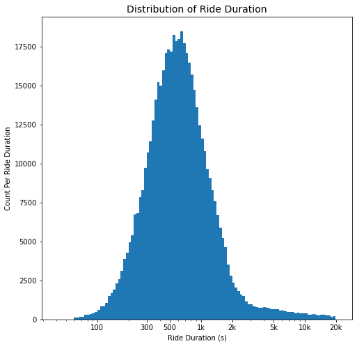

```python
# Setting bin size and bins
log_binsize = 0.025
bins = 10 ** np.arange(1.6, np.log10(df['duration_sec'].max())+log_binsize, log_binsize)

# distribution of ride duration
plt.figure(figsize=[8, 8])
plt.hist(data = df, x = 'duration_sec', bins = bins)
plt.title('Distribution of Ride Duration', fontsize = 14)
plt.xscale('log')
plt.xticks([100, 300, 500, 1e3, 2e3, 5e3, 1e4, 2e4], [100, 300, 500, '1k', '2k', '5k', '10k', '20k'])
plt.xlabel('Ride Duration (s)', fontsize =10)
plt.ylabel('Count Per Ride Duration', fontsize =10)
plt.show();
```

## 0.3. Distribution of Start Hour

Using the 24 hout format, the start hour measures the exact hour a ride is taken. The values of the variable ranges from `01` t0 `24`, with `01` as the 1st representing 01:00 am and `24` as the 24th hour representing 00:00 am also known as midnight.

The distribution of the start hour variable is bimodal and slightly skewed to the left. Using the 24-hour format, most rides recorded occur between the 7th and 19th hour which is usually interpreted to be between 7:00am and 7:00pm. The 17th hour (5:00 pm) holds the most number of rides. There are no rides recorded for the 24th hour which is reasonable since this hour is usually interpreted as midnight.

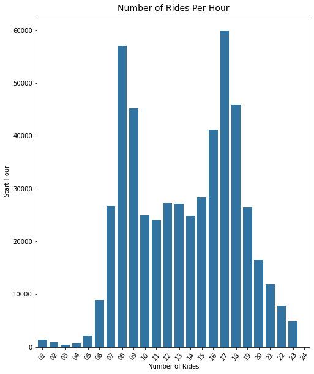

```python
# Setting plot size and base color
plt.figure(figsize = [8, 10])
default_color = sb.color_palette()[0]

# Plotting number of rides per hour
sb.countplot(data = df, x = 'start_hour', color = default_color)
plt.title('Number of Rides Per Hour', fontsize = 14)
plt.xticks(rotation = 50)
plt.xlabel('Number of Rides', fontsize =10)
plt.ylabel('Start Hour', fontsize =10)
plt.show()
```

## 0.4. Distribution of Start Month and Day

Start month and day represents the 12 month period and the 7 days of the week for each recorde bike ride. Both variables are ordered with start month ranging from `January` to `December` and start day ranging from `Sunday` to `Saturday`.

For start day, most of the rides are significantly centered around weekdays (Monday, Tuesday, Wednesday, Thursday, Friday) compared to weekends (Saturday, Sunday). Of all the days, Tuesday is seen to have the most rides. For start month it can be seen that no rides were recorded for the month of `January` to `May`. However, rides were recorded from the month of `June` to `December` with `October` recording the highest number of rides.

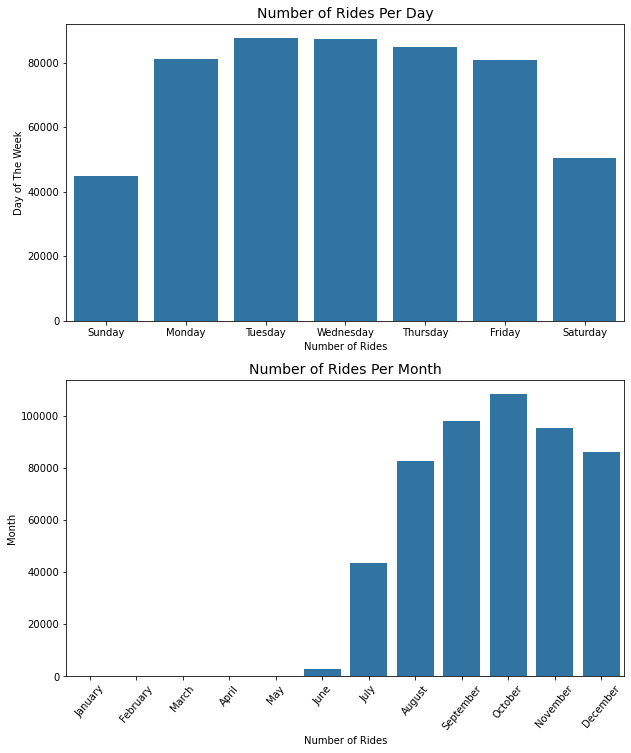

```python
# Setting plot size and base color
fig, ax = plt.subplots(nrows=2, figsize = [10,12])
default_color = sb.color_palette()[0]

# Plotting number of rides per day
sb.countplot(data = df, x = 'start_day', color = default_color, ax = ax[0])
ax[0].set_title('Number of Rides Per Day', fontsize = 14)
ax[0].set_xlabel('Number of Rides', fontsize=10)
ax[0].set_ylabel('Day of The Week', fontsize=10)

# Plotting number of rides per month
sb.countplot(data = df, x = 'start_month', color = default_color, ax = ax[1])
ax[1].set_title('Number of Rides Per Month', fontsize = 14)
ax[1].set_xlabel('Number of Rides', fontsize =10)
ax[1].set_ylabel('Month', fontsize =10)
plt.xticks(rotation = 50)
plt.show()
```

## 0.5. Distribution of User Type

The users describe the people who took bike rides in the the year 2017. The types of users vary between `Customers` and `Subscribers`

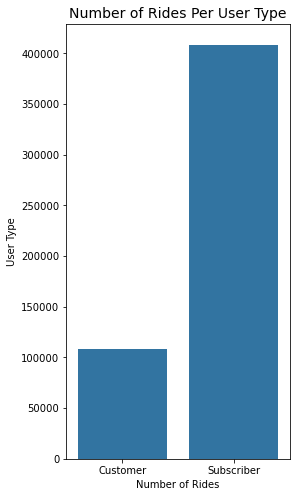

```python
# Setting plot size and base color
plt.figure(figsize = [4,8])
default_color = sb.color_palette()[0]

# Plotting number of rides per user type
sb.countplot(data = df, x = 'user_type', color = default_color)
plt.title('Number of Rides Per User Type', fontsize = 14)
plt.xlabel('Number of Rides', fontsize =10)
plt.ylabel('User Type', fontsize =10)
plt.show();
```

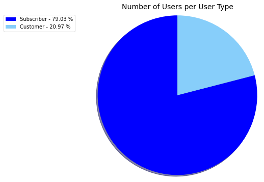

```python
## plotting a pie chart to sow the percentege of users per user type
colors = ['blue', 'lightskyblue']
plt.subplots(figsize = [6, 6])

percent = 100.*users.no_users/users.no_users.sum()
patches, texts = plt.pie(users.no_users, colors=colors, startangle=90, radius=1.2, shadow = True)
labels = ['{0} - {1:1.2f} %'.format(i,j) for i,j in zip(users['index'], percent)]

sort_legend = True
if sort_legend:
    patches, labels, dummy =  zip(*sorted(zip(patches, labels, users.no_users),
                                          key=lambda x: x[2],
                                          reverse=True))

plt.legend(patches, labels, loc='upper right', bbox_to_anchor=(-0.1, 1.),
           fontsize=10)
plt.title('Number of Users per User Type', fontsize = 14);
```

## 0.6. Distribution of Top 10 Start Stations

The start stations indicates the location each bike ride started from. There are 272 unique stations in the dataset which cannot be plotted all at once. The top 10 start stations are therefore plotted instead. It is observed that the largest number of rides were taken at `San Francisco Ferry Building (Harry Bridges Plaza)`.

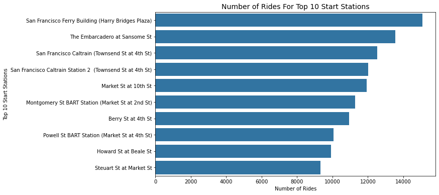

```python
# Setting the plot size and base color
plt.figure(figsize = [10, 6])
base_color = sb.color_palette()[0]

# Number of rides per top 10 start station
start_station_order = df['start_station_name'].value_counts().sort_values(ascending = False).index
sb.countplot(data = df, y = 'start_station_name', color = base_color, order = start_station_order[:10], orient = 'h')
plt.title('Number of Rides For Top 10 Start Stations', fontsize = 14)
plt.xlabel('Number of Rides', fontsize=10)
plt.ylabel('Top 10 Start Stations', fontsize=10)
plt.show();
```

## 0.7. Duration By User Type, Start Day, Hour and Month

Plotting duration on a logarithmic scale against each of the categorical variables (start day, hour, month and user type) produces insight into the variation of ride duration across variables. It can also be seen that the median ride duration was higher for `Customers`, and weekends (`Saturday` and `Sunday)`. The median ride duration was also higher between `01:00`am and `03:00`am and almost equal for the months of `July`, `August`, `September`, `October` and `November`.

The difference in the ride duration during weekdays or weekends may be affected by the user type, start hour of start month of the ride. The effect of these categories across each other on the ride duration will be seen in the multivariate analysis.

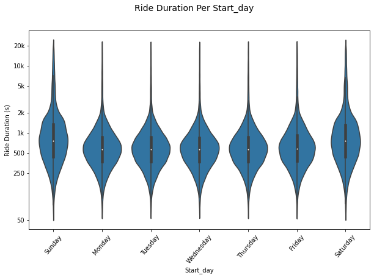

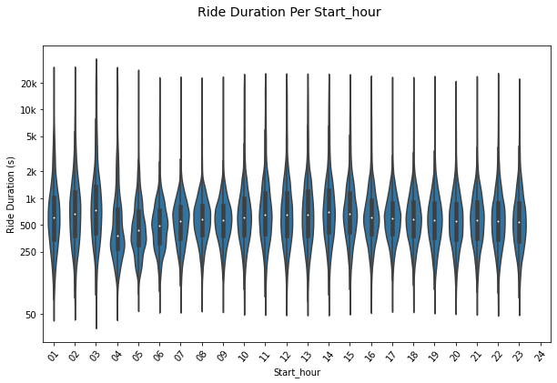

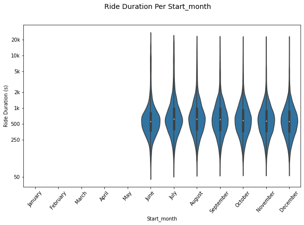

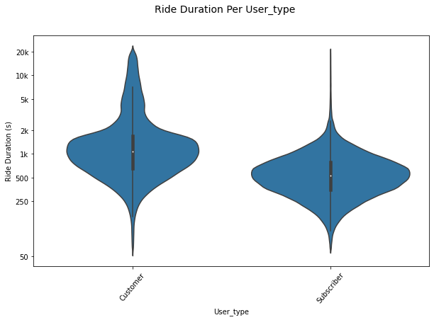

```python
# applying plotting function to show plots

violin_plot('start_day', sb.color_palette()[0])
violin_plot('start_hour', sb.color_palette()[0])
violin_plot('start_month', sb.color_palette()[0])
violin_plot('user_type', sb.color_palette()[0])
```

## 0.8. Duration By Start Month and Day for Different Users

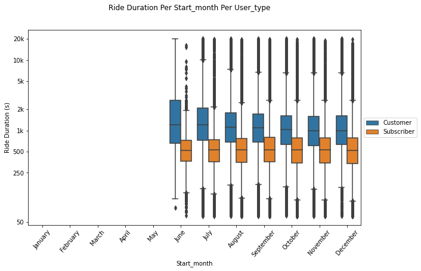

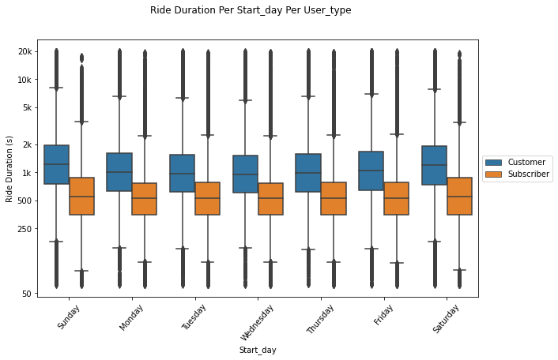

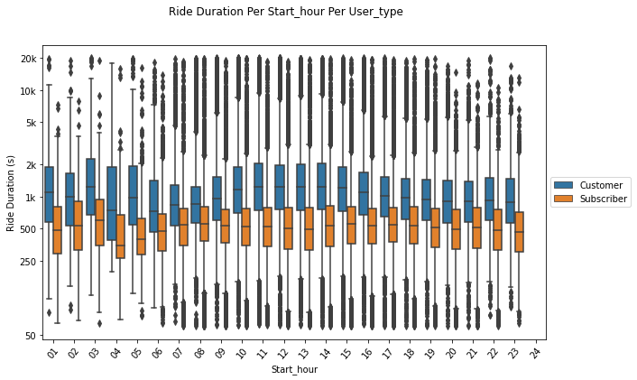

```python
box_plot('start_month', 'user_type')
box_plot('start_day', 'user_type')
box_plot('start_hour', 'user_type')
```

## 0.9. Ride Duration by Start Month and Hour Per Day

The plot shows the variation and hierachy in the ride duration across the start month and start hour for all the days of the week with longer rides usually taken on weekends (`Saturday` and `Sunday`) per month and hour.

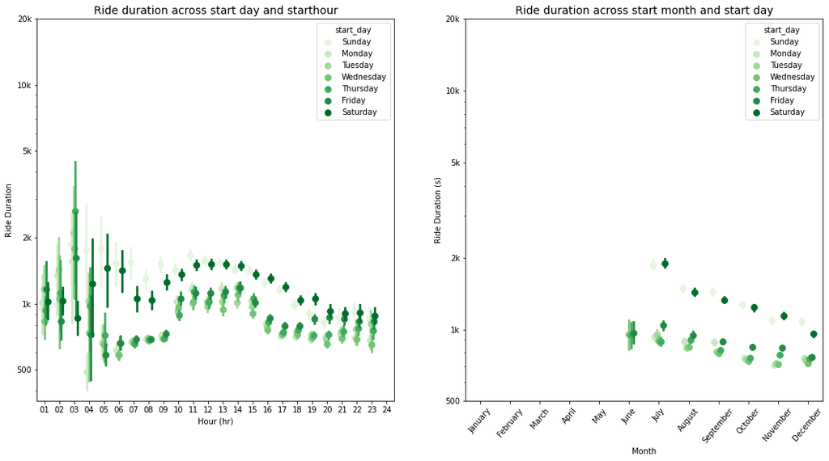

```python
# Setting the plot sizes
fig, ax = plt.subplots(ncols = 2, figsize = [18,9])

# Subplot 1 : start day and hour vs duration
sb.pointplot(data = df, x = 'start_hour', y = 'duration_sec', hue = 'start_day',
           palette = 'Greens', linestyles = '', dodge = 0.4, ax = ax[0])
ax[0].set_title('Ride duration across start day and starthour', fontsize =14)
ax[0].set_ylabel('Ride Duration', fontsize =10)
ax[0].set_xlabel('Hour (hr)')
ax[0].set_yscale('log')
ax[0].set_yticks([500, 1e3, 2e3, 5e3, 1e4, 2e4])
ax[0].set_yticklabels([500, '1k', '2k', '5k', '10k', '20k'])
ax[0].set_yticklabels([],minor = True)

# Subplot 2 : start day and month vs duration
sb.pointplot(data = df, x = 'start_month', y = 'duration_sec', hue = 'start_day',
           palette = 'Greens', linestyles = '', dodge = 0.4, ax = ax[1])
ax[1].set_title('Ride duration across start month and start day', fontsize = 14)
ax[1].set_xlabel('Month', fontsize = 10)
ax[1].set_ylabel('Ride Duration (s)', fontsize = 10)
ax[1].set_yscale('log')
ax[1].set_yticks([500, 1e3, 2e3, 5e3, 1e4, 2e4])
ax[1].set_yticklabels([500, '1k', '2k', '5k', '10k', '20k'])
ax[1].set_yticklabels([],minor = True)
plt.xticks(rotation = 50)


plt.show();
```

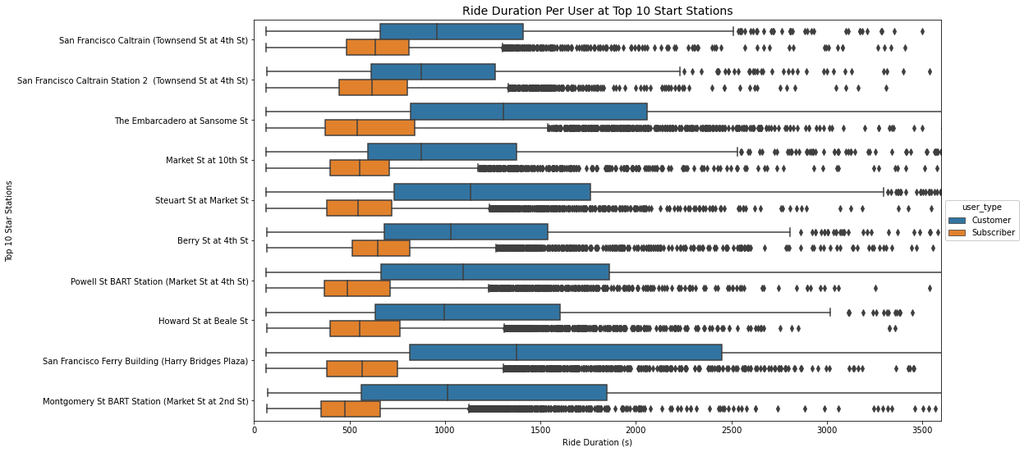

```python
# Setting the plot size and base color
plt.figure(figsize = [15, 9])
base_color = sb.color_palette()[0]

# Plotting top 10 start station per number of rides per user
ax = sb.boxplot(data = top10_station, x = 'duration_sec', y = 'start_station_name', hue = 'user_type', orient = 'h')
ax.legend(loc = 6, bbox_to_anchor = (1.0, 0.5), ncol = 1, framealpha = 1, title = 'user_type')
ax.set_title('Ride Duration Per User at Top 10 Start Stations', fontsize =14)
ax.set_ylabel('Top 10 Star Stations', fontsize =10)
ax.set_xlabel('Ride Duration (s)', fontsize =10)
ax.set_xlim(0, 3600)
plt.show();
```